# Testing Bernoulli and Binomial parameters

Test

Goodness-of-fit

Bernoulli parameter

Sex ratio

Chi-square

Published

September 2, 2024

```r
stopifnot(
  require(patchwork),
  require(glue),
  require(here),
  require(tidyverse),
  require(plotly),
  require(DT),
  require(GGally),
  require(ggforce),
  require(ggfortify)
)

tidymodels::tidymodels_prefer(quiet = TRUE)

old_theme <-theme_set(theme_minimal(base_size=9, base_family = "Helvetica"))
```

- **M1 MIDS/MFA**
- **[Université Paris Cité](https://www.u-paris.fr)**
- Année 2024-2025
- [Course Homepage](https://stephane-v-boucheron.fr/courses/scidon)
- [Moodle](https://moodle.u-paris.fr/course/view.php?id=6143)

**Objectives**

## Hypothesis testing

Download ‘Naissances totales par sexe’ from URL `https://www.ined.fr/fichier/s_rubrique/168/t35.fr.xls` from [INED](https://www.ined.fr/).

```r
path_data <- 'DATA'
births_fr_path <- here(path_data, 't35.fr.xls')
births_fr_url <- 'https://www.ined.fr/fichier/s_rubrique/168/t35.fr.xls'

if (!file.exists(births_fr_path)) {
  download.file(births_fr_url, births_fr_path, mode = "wb")
}
```

```r
births_fr <-  readxl::read_excel(births_fr_path, skip = 3)

births_fr <- births_fr[2:122, ]


births_fr <- births_fr |>
  rename(year= `Répartition par sexe et vie`,
         n_livebirths = `Ensemble des nés vivants`,
         n_live_boys = `Nés vivants - Garçons`,
         n_stillbirths = `Ensemble des enfants sans vie`,
         n_still_boys =`Enfants sans vie - Garçons`) |>
  select(year, starts_with('n_'))

#births_fr <- births_fr[1:122,]

births_fr |>
  glimpse()
```

```
Rows: 121
Columns: 5
$ year          <chr> "1901", "1902", "1903", "1904", "1905", "1906", "1907", …
$ n_livebirths  <dbl> 917075, 904434, 884498, 877091, 865604, 864745, 829632, …
$ n_live_boys   <dbl> 468125, 462097, 451510, 447651, 442397, 441358, 424692, …
$ n_stillbirths <dbl> 32410, 32000, 31076, 30673, 30108, 29671, 29208, 29834, …
$ n_still_boys  <chr> "18522", "18172", "17875", "17299", "17289", "16977", "1…
```

**Null Hypothesis**

The probability of a live newborn baby being a boy is $p_0 =.5121244$

**Alternative Hypothesis**

The probability of a live newborn baby being a boy is $p > p_0=.5121244$

Data and modeling

Probability of observed data if live newborn sex is distributed according to Bernoulli($p$)

$$\left(\frac{p(1-p_0)}{(1-p)p_0}\right)^{n_g} \times \left(\frac{1-p}{1-p_0}\right)^n$$

The Likelihood Ratio increases with respect to $n_g$ for all values of $p > p_0$.

Comparing the likelihood ratio to a threshold amounts to compare $n_g$ to a(nother) threshold.

Here Likelihood Ratio testing is motivated by common sense and can be justified by Theory (Neyman-Pearson’s Lemma).

**Definition: Error of the first kind (Type I error)**

The error of the first kind occurs when the null hypothesis is true, but the test would reject it.

**Definition: Error of the second kind (Type II error)**

The error of the second kind occurs if the alternative hypothesis is true but the test is deciding in favor of the null-hypothesis.

The next lemma justifies our interest in Likelihood Ratio testing

**Lemma (Neyman-Pearson, simplified)**

When testing a *simple* null hypothesis $H_0 : X \sim P_0$ against a simple alternative $H_1 : X \sim P_1$, if there exists a threshold $\tau$ such that the test $T$ with *critical region* $\{x : p_1(x) \geq \tau \times p_0(x) \}$ has type I error probability equal to $\alpha \in (0,1)$, then for any test $T'$
$$P_0\{ T'(x) =1\} \leq \alpha \quad \Rightarrow \quad P_1\{ T'(x) =1\}\leq P_1\{ T(x) =1\}$$

**Level (of significance)**

The level of significance is defined as the fixed probability of wrong elimination of null hypothesis when in fact, it is true. The level of significance is stated to be the probability of type I error and is preset by the researcher.

## Testing a Bernoulli parameter

We think of the sex of newborns as a sequence of independent Bernoulli trials. Under the simplest model, all Bernoulli trials have the same “success” probability.In principle, we have no a priori knowledge of the “success” probability. We take $p_0$ as the empirical frequency of livebirth of boys throughout the century.

```r
births_fr |>
  summarise(tot=sum(n_livebirths, na.rm = T),
            tot_boys=sum(n_live_boys, na.rm = T),
            msr=tot_boys/tot)
```

```
# A tibble: 1 × 3
       tot tot_boys   msr
     <dbl>    <dbl> <dbl>
1 92078262 47155839 0.512
```

We compute now for each year, the probability that a binomial random variable with size *number of livebirths* during the year and success probability $p_0$, exceeds the number of livebirths of boys during that year, the result is denoted by `pval`.

```r
p_0 <- 0.5121244

births_fr <- births_fr |>
  mutate(pval = pbinom(n_live_boys, size = n_livebirths, prob = p_0, lower.tail = F)) |>
  relocate(pval, .after = year)
```

*Under our null hypothesis*, `pval` is a random variable, and it is (almost) uniformly distributed over $[0,1]$. If we want a testing procedure with type I error $\alpha$, we can decide to reject the null hypothesis when `pval` (usually called the $p$-value) is less than $\alpha$.

Agree on Type I error probability ($\alpha$) equal to $.05$.

```r
births_fr |>
  DT::datatable()  |>
  DT::formatSignif('pval', digits=3) |>
  DT::formatStyle(
  'pval',
  backgroundColor = DT::styleInterval(c(.05, 1), values = c('red', 'lightgreen', 'white'))
)
```

|  | year | pval | n_livebirths | n_live_boys | n_stillbirths | n_still_boys |
| --- | --- | --- | --- | --- | --- | --- |
| 1 | 1901 | 0.9993087374132263 | 917075 | 468125 | 32410 | 18522 |
| 2 | 1902 | 0.9887808435985205 | 904434 | 462097 | 32000 | 18172 |
| 3 | 1903 | 0.9990676650394912 | 884498 | 451510 | 31076 | 17875 |
| 4 | 1904 | 0.9994515500465753 | 877091 | 447651 | 30673 | 17299 |
| 5 | 1905 | 0.9734443502240056 | 865604 | 442397 | 30108 | 17289 |
| 6 | 1906 | 0.9993674237519256 | 864745 | 441358 | 29671 | 16977 |
| 7 | 1907 | 0.655566430623111 | 829632 | 424692 | 29208 | 16675 |
| 8 | 1908 | 0.2988091559717397 | 848982 | 435027 | 29834 | 16914 |
| 9 | 1909 | 0.8580602732199734 | 824739 | 421882 | 28688 | 16378 |
| 10 | 1910 | 0.8776641810072581 | 828140 | 423581 | 28566 | 16064 |

[output cut: 111 more lines]

## Geissler data, goodness of fit testing.

From package `vcdExtra`

> Geissler (1889) published data on the distributions of boys and girls in families in Saxony, collected for the period 1876-1885. The Geissler data tabulates the family composition of 991,958 families by the number of boys and girls listed in the table supplied by Edwards

```r
Geissler <- vcdExtra::Geissler
Geissler |>  glimpse()
```

```
Rows: 90
Columns: 4
$ boys  <int> 0, 0, 0, 0, 0, 0, 0, 0, 0, 0, 0, 0, 1, 1, 1, 1, 1, 1, 1, 1, 1, 1…
$ girls <dbl> 1, 2, 3, 4, 5, 6, 7, 8, 9, 10, 11, 12, 0, 1, 2, 3, 4, 5, 6, 7, 8…
$ size  <dbl> 1, 2, 3, 4, 5, 6, 7, 8, 9, 10, 11, 12, 1, 2, 3, 4, 5, 6, 7, 8, 9…
$ Freq  <int> 108719, 42860, 17395, 7004, 2839, 1096, 436, 161, 66, 30, 8, 3, …
```

We isolate families of size $12$.

```r
big_families <- Geissler |>
  filter(size==12) |>
  select(-size, -girls)
```

There are 6115 of them.

```r
big_families |>
  pivot_wider(names_from = boys, values_from = Freq) |>
  knitr::kable()
```

| 0 | 1 | 2 | 3 | 4 | 5 | 6 | 7 | 8 | 9 | 10 | 11 | 12 |
| --- | --- | --- | --- | --- | --- | --- | --- | --- | --- | --- | --- | --- |
| 3 | 24 | 104 | 286 | 670 | 1033 | 1343 | 1112 | 829 | 478 | 181 | 45 | 7 |

According to our simple null hypothesis, the large families compositions should be distributed according to a binomial distribution with size $12$ and success probability $p_0$.

We can perform a goodness of fit test for this distribution. The Chi-square goodness of fit test comes to mind

```r
expected <- dbinom(0:12, 12, p_0)
observed <- big_families$Freq

chisq.test(observed, p=expected) |>
  broom::tidy() |>
  knitr::kable()
```

```
Warning in chisq.test(observed, p = expected): Chi-squared approximation may be
incorrect
```

| statistic | p.value | parameter | method |
| --- | --- | --- | --- |
| 130.3315 | 0 | 12 | Chi-squared test for given probabilities |

We merge rare events as an attempt to avoid the warning.

```r
expected_collapsed <- expected[2:12]
expected_collapsed[1] <- expected_collapsed[1]+ expected[1]
expected_collapsed[11] <- expected_collapsed[11]+ expected[13]

observed_collapsed <- observed[2:12]
observed_collapsed[1] <- observed_collapsed[1]+ observed[1]
observed_collapsed[11] <- observed_collapsed[11]+ observed[13]
```

```r
chisq.test(observed_collapsed, p=expected_collapsed) |>
  broom::tidy() |>
  knitr::kable()
```

| statistic | p.value | parameter | method |
| --- | --- | --- | --- |
| 124.9965 | 0 | 10 | Chi-squared test for given probabilities |

We are led to reject the null hypothesis for all reasonable type I error probabilities.

Let us compare the empirical distribution and the theoretical distribution of large families compisitions

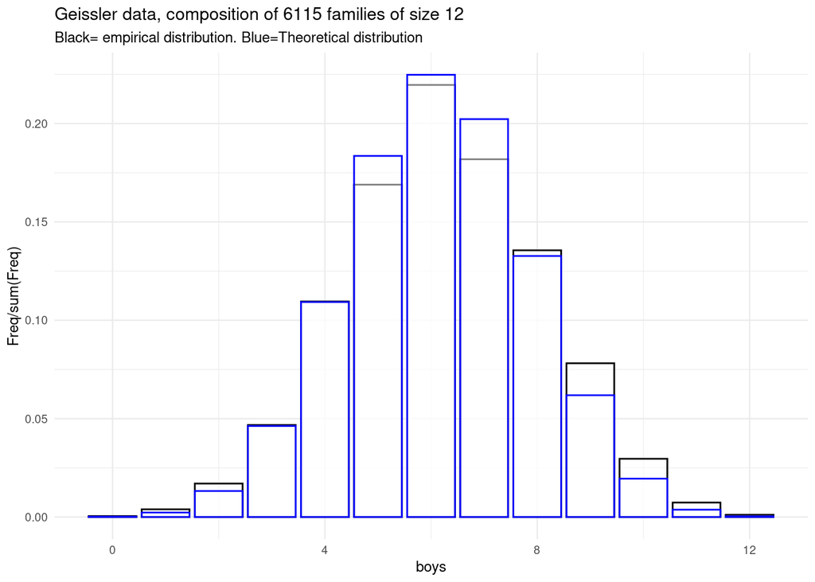

```r
p <- big_families |>
  ggplot() +
  aes(x= boys, y=Freq/sum(Freq)) +
  geom_col(fill="white", color="black", alpha=.5) +
  geom_col(aes(y=expected), fill="white", color="blue", alpha=.5) +
  labs(
    title="Geissler data, composition of 6115 families of size 12",
    subtitle="Black= empirical distribution. Blue=Theoretical distribution"
  )

p
```

Using logarithmic scale on the `y` axis emphasizes the overdispersion of the empirical distribution.

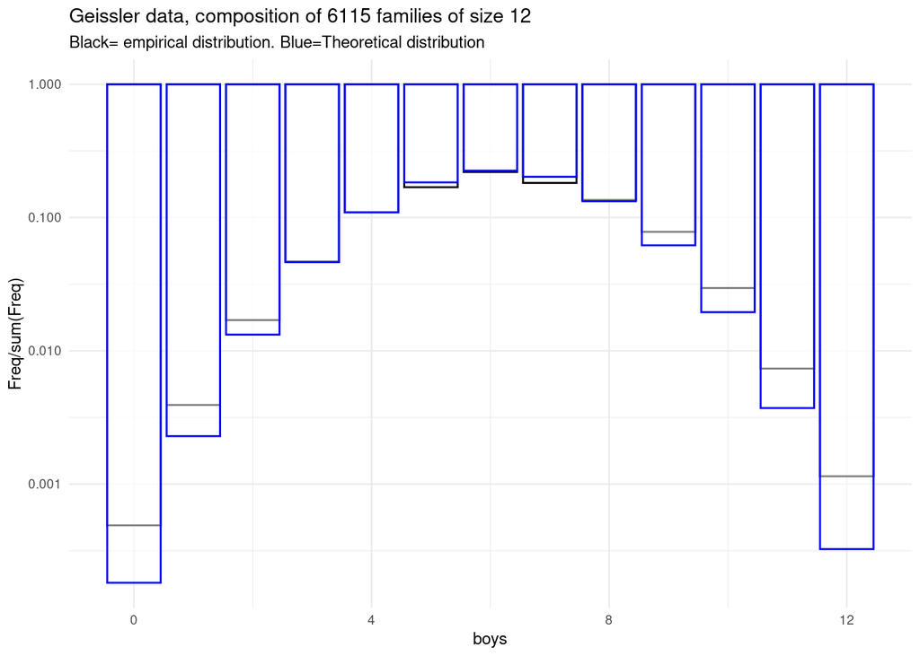

```r
p + scale_y_log10()
```